# Cocaine Withdrawal in Rats and Protein Expression

Priscilla Cuellar-Rocha

2023-08-08

# Analysis of protein expression in rats experiencing cocaine withdrawal

- Data gathered by Dr. Karen Szumkslki, Behavioral and Neural Genetics (BANG) LAB
- Principal Investigator: Karen Szumkslki
- Research Assistants: Priscilla Cuellar-Rocha
- Graduate Research Assistants: Fernando Cano

  Previous research has found that cue-elicited craving incubation can be tested from protein expression. Proteins are found all throughout the brain and the body. The types of proteins used in this study have been found to have a relationship with drug addiction craving. This report presents analysis for the data called rattyFatty gathered in the Bang Lab for rats that were given cocaine.

### Research Question

The data gathered are from rats who were given cocaine via a Skinner-based operant conditioned environment. One group of rats were given cocaine while another different group of rats were control. During cue-testing the right lever press gives us those cues only. Every time they got that reward they got a tone/light cue. Which then became associated with the reward. Those cues developed a reinforcing properties. Both groups of rats would then either be placed in an early withdrawal (3 day) period or in a late withdrawal (30 day) period.

### Methods

A 2x2 Anova analysis was conducted. The predictor variables will be if they are either given cocaine or a sham; Sham being the control group. The second predictor variable will be when given cocaine will the rat be placed in a 3 day or 30 day abstinence period. The Outcome variable will be protein expression: Glutamate1, mTOR, pAKT, Homer1, AKT, and Homer2. It will be measured through a boxplot graph to quantify the proteins.

[output not shown]

```r
rattyFatty <- read.csv("Raw Data/Cocaine_PL.csv")
colnames(rattyFatty)[5] ="Glutmate1"
colnames(rattyFatty)[6] ="mTOR"
colnames(rattyFatty)[7] ="pAKT"
colnames(rattyFatty)[8] ="Homer1"
colnames(rattyFatty)[9] ="AKT"
colnames(rattyFatty)[10] ="Homer2"

ratMelt <- melt(rattyFatty,
                measure.vars=c("Glutmate1","mTOR", "pAKT", "Homer1", "AKT", "Homer2"),
                  variable.name=c("protein"),
                  value.name=c("expression"))


ratMelt$WD <- factor(ratMelt$WD)
ratMelt$Group <- factor(ratMelt$Group, labels = c("Cocaine", "Control"))
```

### Predictions

- The null hypothesis is that rats in a late withdrawal (30WD) will exhibit higher craving than the early withdrawal (3WD) rats as quantified by protein expression.

# Results

### Cocaine withdrawal and its Protein expression on male rats Graph

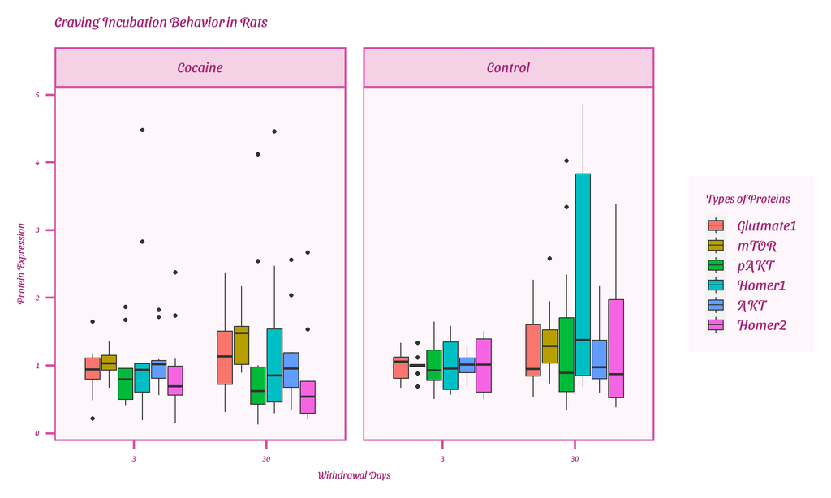

```r
ratPlot <- ggplot(data=ratMelt, aes(x=WD, y=expression, fill=protein)) +
  geom_boxplot() + facet_wrap(~Group) +
  labs(x="Withdrawal Days", y="Protein Expression", fill = "Types of Proteins") +
  theme_gray(base_size=30) +
  theme_barbie() +
  ggtitle("Craving Incubation Behavior in Rats")


ratPlot
```

### Data Analysis in a 2x2 ANOVA

```r
letsee <- aov(expression~WD*Group*protein+Error(Animal_ID),data=ratMelt)

summary(letsee)
```

```
##
## Error: Animal_ID
##           Df Sum Sq Mean Sq F value Pr(>F)
## WD         1   6.72   6.725   2.627  0.113
## Group      1   1.54   1.544   0.603  0.442
## WD:Group   1   1.49   1.490   0.582  0.450
## Residuals 41 104.95   2.560
##
## Error: Within
##                   Df Sum Sq Mean Sq F value  Pr(>F)
## protein            5   6.03  1.2064   4.709 0.00043 ***
## WD:protein         5   2.06  0.4118   1.608 0.15948
## Group:protein      5   1.51  0.3024   1.181 0.31987
## WD:Group:protein   5   2.55  0.5093   1.988 0.08180 .
## Residuals        205  52.52  0.2562
## ---
## Signif. codes:  0 '***' 0.001 '**' 0.01 '*' 0.05 '.' 0.1 ' ' 1
```

# Discussion

Although previous research has found that cocaine incubation does increase with longer days. The data found in this study that it suggests otherwise. This difference could perhaps be the result of either 1) the cue-based animal design had an error that resulted in the rat not having a long enough incubation rate, or 2) the error occurred during the immunoblotting phase.